# Risk Factor Analysis

## Outcome Variable

**Outcome Variable:** whz

## Predictor Variables

**Intervention Variable:** feducyrs

**Adjustment Set:**

- arm
- W_mage
- meducyrs
- hhwealth_quart
- W_mhtcm
- W_mwtkg
- W_mbmi
- W_gagebrth
- W_birthwt
- W_birthlen
- single
- delta_W_mage
- delta_meducyrs
- delta_hhwealth_quart
- delta_W_mhtcm
- delta_W_mwtkg
- delta_W_mbmi
- delta_W_gagebrth
- delta_W_birthwt
- delta_W_birthlen
- delta_single

## Stratifying Variables

The analysis was stratified on these variable(s):

- agecat
- studyid
- country

## Data Summary

| agecat | studyid | country | feducyrs | n_cell | n | outcome_variable |
| --- | --- | --- | --- | --- | --- | --- |
| Birth | COHORTS | GUATEMALA | High | 136 | 718 | whz |
| Birth | COHORTS | GUATEMALA | Low | 311 | 718 | whz |
| Birth | COHORTS | GUATEMALA | Medium | 271 | 718 | whz |
| Birth | COHORTS | INDIA | High | 507 | 1291 | whz |
| Birth | COHORTS | INDIA | Low | 414 | 1291 | whz |
| Birth | COHORTS | INDIA | Medium | 370 | 1291 | whz |
| Birth | COHORTS | PHILIPPINES | High | 994 | 2728 | whz |
| Birth | COHORTS | PHILIPPINES | Low | 773 | 2728 | whz |
| Birth | COHORTS | PHILIPPINES | Medium | 961 | 2728 | whz |
| Birth | GMS-Nepal | NEPAL | High | 162 | 640 | whz |
| Birth | GMS-Nepal | NEPAL | Low | 266 | 640 | whz |
| Birth | GMS-Nepal | NEPAL | Medium | 212 | 640 | whz |
| Birth | JiVitA-3 | BANGLADESH | High | 4049 | 17367 | whz |
| Birth | JiVitA-3 | BANGLADESH | Low | 7452 | 17367 | whz |
| Birth | JiVitA-3 | BANGLADESH | Medium | 5866 | 17367 | whz |
| Birth | JiVitA-4 | BANGLADESH | High | 510 | 2323 | whz |
| Birth | JiVitA-4 | BANGLADESH | Low | 913 | 2323 | whz |
| Birth | JiVitA-4 | BANGLADESH | Medium | 900 | 2323 | whz |
| Birth | MAL-ED | BANGLADESH | High | 44 | 119 | whz |
| Birth | MAL-ED | BANGLADESH | Low | 33 | 119 | whz |
| Birth | MAL-ED | BANGLADESH | Medium | 42 | 119 | whz |
| Birth | MAL-ED | INDIA | High | 7 | 23 | whz |
| Birth | MAL-ED | INDIA | Low | 13 | 23 | whz |
| Birth | MAL-ED | INDIA | Medium | 3 | 23 | whz |
| Birth | MAL-ED | NEPAL | High | 3 | 9 | whz |
| Birth | MAL-ED | NEPAL | Low | 3 | 9 | whz |
| Birth | MAL-ED | NEPAL | Medium | 3 | 9 | whz |
| Birth | MAL-ED | PERU | High | 84 | 190 | whz |
| Birth | MAL-ED | PERU | Low | 56 | 190 | whz |
| Birth | MAL-ED | PERU | Medium | 50 | 190 | whz |

[output cut: 135 more lines]

The following strata were considered:

- agecat: 24 months, studyid: COHORTS, country: GUATEMALA
- agecat: 24 months, studyid: COHORTS, country: INDIA
- agecat: 24 months, studyid: COHORTS, country: PHILIPPINES
- agecat: 24 months, studyid: GMS-Nepal, country: NEPAL
- agecat: 24 months, studyid: JiVitA-3, country: BANGLADESH
- agecat: 24 months, studyid: JiVitA-4, country: BANGLADESH
- agecat: 24 months, studyid: LCNI-5, country: MALAWI
- agecat: 24 months, studyid: MAL-ED, country: BANGLADESH
- agecat: 24 months, studyid: MAL-ED, country: INDIA
- agecat: 24 months, studyid: MAL-ED, country: NEPAL
- agecat: 24 months, studyid: MAL-ED, country: PERU
- agecat: 24 months, studyid: MAL-ED, country: SOUTH AFRICA
- agecat: 24 months, studyid: MAL-ED, country: TANZANIA, UNITED REPUBLIC OF
- agecat: 24 months, studyid: NIH-Crypto, country: BANGLADESH
- agecat: 24 months, studyid: PROBIT, country: BELARUS
- agecat: 24 months, studyid: PROVIDE, country: BANGLADESH
- agecat: 24 months, studyid: TanzaniaChild2, country: TANZANIA, UNITED REPUBLIC OF
- agecat: 24 months, studyid: ZVITAMBO, country: ZIMBABWE
- agecat: 6 months, studyid: COHORTS, country: GUATEMALA
- agecat: 6 months, studyid: COHORTS, country: INDIA
- agecat: 6 months, studyid: COHORTS, country: PHILIPPINES
- agecat: 6 months, studyid: GMS-Nepal, country: NEPAL
- agecat: 6 months, studyid: JiVitA-3, country: BANGLADESH
- agecat: 6 months, studyid: JiVitA-4, country: BANGLADESH
- agecat: 6 months, studyid: LCNI-5, country: MALAWI
- agecat: 6 months, studyid: MAL-ED, country: BANGLADESH
- agecat: 6 months, studyid: MAL-ED, country: INDIA
- agecat: 6 months, studyid: MAL-ED, country: NEPAL
- agecat: 6 months, studyid: MAL-ED, country: PERU
- agecat: 6 months, studyid: MAL-ED, country: SOUTH AFRICA
- agecat: 6 months, studyid: MAL-ED, country: TANZANIA, UNITED REPUBLIC OF
- agecat: 6 months, studyid: NIH-Crypto, country: BANGLADESH
- agecat: 6 months, studyid: PROBIT, country: BELARUS
- agecat: 6 months, studyid: PROVIDE, country: BANGLADESH
- agecat: 6 months, studyid: SAS-CompFeed, country: INDIA
- agecat: 6 months, studyid: SAS-FoodSuppl, country: INDIA
- agecat: 6 months, studyid: TanzaniaChild2, country: TANZANIA, UNITED REPUBLIC OF
- agecat: 6 months, studyid: ZVITAMBO, country: ZIMBABWE
- agecat: Birth, studyid: COHORTS, country: GUATEMALA
- agecat: Birth, studyid: COHORTS, country: INDIA
- agecat: Birth, studyid: COHORTS, country: PHILIPPINES
- agecat: Birth, studyid: GMS-Nepal, country: NEPAL
- agecat: Birth, studyid: JiVitA-3, country: BANGLADESH
- agecat: Birth, studyid: JiVitA-4, country: BANGLADESH
- agecat: Birth, studyid: MAL-ED, country: BANGLADESH
- agecat: Birth, studyid: MAL-ED, country: INDIA
- agecat: Birth, studyid: MAL-ED, country: NEPAL
- agecat: Birth, studyid: MAL-ED, country: PERU
- agecat: Birth, studyid: MAL-ED, country: SOUTH AFRICA
- agecat: Birth, studyid: MAL-ED, country: TANZANIA, UNITED REPUBLIC OF
- agecat: Birth, studyid: NIH-Crypto, country: BANGLADESH
- agecat: Birth, studyid: PROBIT, country: BELARUS
- agecat: Birth, studyid: PROVIDE, country: BANGLADESH
- agecat: Birth, studyid: SAS-CompFeed, country: INDIA
- agecat: Birth, studyid: ZVITAMBO, country: ZIMBABWE

### Dropped Strata

Some strata were dropped due to rare outcomes:

- agecat: Birth, studyid: MAL-ED, country: INDIA
- agecat: Birth, studyid: MAL-ED, country: NEPAL
- agecat: 24 months, studyid: TanzaniaChild2, country: TANZANIA, UNITED REPUBLIC OF

## Methods Detail

We’re interested in the causal parameters $E[Y_a]$ for all values of $a \in \mathcal{A}$. These parameters represent the mean outcome if, possibly contrary to fact, we intervened to set all units to have $A=a$. Under the randomization and positivity assumptions, these are identified by the statistical parameters $\psi_a=E_W[E_{Y|A,W}(Y|A=a,W)]$. In addition, we’re interested in the mean of $Y$, $E[Y]$ under no intervention (the observed mean). We will estimate these parameters by using SuperLearner to fit the relevant likelihood factors – $E_{Y|A,W}(Y|A=a,W)$ and $p(A=a|W)$, and then updating our likelihood fit using a joint TMLE.

For unadjusted analyses ($W=\{\}$), initial likelihoods were estimated using Lrnr_glm to estimate the simple $E(Y|A)$ and Lrnr_mean to estimate $p(A)$. For adjusted analyses, a small library containing Lrnr_glmnet, Lrnr_xgboost, and Lrnr_mean was used.

Having estimated these parameters, we will then use the delta method to estimate relative risks and attributable risks relative to a prespecified baseline level of $A$.

# Results Detail

## Results Plots

[figure not shown]

[figure not shown]

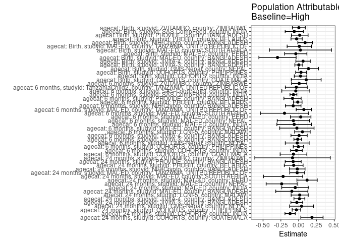

## Results Table

### Parameter: TSM

| agecat | studyid | country | intervention_level | baseline_level | estimate | ci_lower | ci_upper |
| --- | --- | --- | --- | --- | --- | --- | --- |
| Birth | COHORTS | GUATEMALA | High | NA | -1.1536682 | -1.3781704 | -0.9291660 |
| Birth | COHORTS | GUATEMALA | Low | NA | -1.0338748 | -1.1949833 | -0.8727664 |
| Birth | COHORTS | GUATEMALA | Medium | NA | -1.1124635 | -1.2856348 | -0.9392922 |
| Birth | COHORTS | INDIA | High | NA | -1.0286539 | -1.1372133 | -0.9200945 |
| Birth | COHORTS | INDIA | Low | NA | -0.9882406 | -1.1045481 | -0.8719331 |
| Birth | COHORTS | INDIA | Medium | NA | -1.0606535 | -1.1905664 | -0.9307405 |
| Birth | COHORTS | PHILIPPINES | High | NA | -0.7553213 | -0.8438477 | -0.6667949 |
| Birth | COHORTS | PHILIPPINES | Low | NA | -0.6146252 | -0.7133019 | -0.5159485 |
| Birth | COHORTS | PHILIPPINES | Medium | NA | -0.6893030 | -0.7751604 | -0.6034457 |
| Birth | GMS-Nepal | NEPAL | High | NA | -1.2544109 | -1.4163252 | -1.0924967 |
| Birth | GMS-Nepal | NEPAL | Low | NA | -1.0269974 | -1.1589204 | -0.8950744 |
| Birth | GMS-Nepal | NEPAL | Medium | NA | -1.1362359 | -1.2974306 | -0.9750411 |
| Birth | JiVitA-3 | BANGLADESH | High | NA | -0.7770241 | -0.8359451 | -0.7181031 |
| Birth | JiVitA-3 | BANGLADESH | Low | NA | -0.7751548 | -0.8109039 | -0.7394056 |
| Birth | JiVitA-3 | BANGLADESH | Medium | NA | -0.7730334 | -0.8063589 | -0.7397080 |
| Birth | JiVitA-4 | BANGLADESH | High | NA | -0.7452635 | -0.8543949 | -0.6361320 |
| Birth | JiVitA-4 | BANGLADESH | Low | NA | -0.6958263 | -0.7941505 | -0.5975022 |
| Birth | JiVitA-4 | BANGLADESH | Medium | NA | -0.6837463 | -0.8065309 | -0.5609616 |
| Birth | MAL-ED | BANGLADESH | High | NA | -0.6512907 | -0.9702016 | -0.3323797 |
| Birth | MAL-ED | BANGLADESH | Low | NA | -1.2553582 | -1.6530423 | -0.8576741 |
| Birth | MAL-ED | BANGLADESH | Medium | NA | -1.0146764 | -1.3381472 | -0.6912056 |
| Birth | MAL-ED | PERU | High | NA | 0.0257814 | -0.1568865 | 0.2084493 |
| Birth | MAL-ED | PERU | Low | NA | -0.1782647 | -0.4368690 | 0.0803396 |
| Birth | MAL-ED | PERU | Medium | NA | 0.0453380 | -0.2477875 | 0.3384634 |
| Birth | MAL-ED | SOUTH AFRICA | High | NA | 0.2810000 | -0.1017325 | 0.6637325 |
| Birth | MAL-ED | SOUTH AFRICA | Low | NA | -0.0364286 | -0.7135146 | 0.6406575 |
| Birth | MAL-ED | SOUTH AFRICA | Medium | NA | 0.8666667 | 0.3467047 | 1.3866286 |
| Birth | MAL-ED | TANZANIA, UNITED REPUBLIC OF | High | NA | 0.7446774 | 0.5287317 | 0.9606232 |
| Birth | MAL-ED | TANZANIA, UNITED REPUBLIC OF | Low | NA | 0.6161538 | 0.1324976 | 1.0998101 |
| Birth | MAL-ED | TANZANIA, UNITED REPUBLIC OF | Medium | NA | 1.2775000 | 0.4059642 | 2.1490358 |

[output cut: 126 more lines]

### Parameter: E(Y)

| agecat | studyid | country | intervention_level | baseline_level | estimate | ci_lower | ci_upper |
| --- | --- | --- | --- | --- | --- | --- | --- |
| Birth | COHORTS | GUATEMALA | NA | NA | -1.0475905 | -1.1510656 | -0.9441155 |
| Birth | COHORTS | INDIA | NA | NA | -1.0020759 | -1.0646599 | -0.9394920 |
| Birth | COHORTS | PHILIPPINES | NA | NA | -0.7218585 | -0.7694262 | -0.6742908 |
| Birth | GMS-Nepal | NEPAL | NA | NA | -1.1161562 | -1.2038617 | -1.0284508 |
| Birth | JiVitA-3 | BANGLADESH | NA | NA | -0.7747631 | -0.7940385 | -0.7554876 |
| Birth | JiVitA-4 | BANGLADESH | NA | NA | -0.6831985 | -0.7361386 | -0.6302583 |
| Birth | MAL-ED | BANGLADESH | NA | NA | -0.9483613 | -1.1437809 | -0.7529418 |
| Birth | MAL-ED | PERU | NA | NA | -0.0145789 | -0.1426994 | 0.1135416 |
| Birth | MAL-ED | SOUTH AFRICA | NA | NA | 0.3060606 | -0.0577506 | 0.6698718 |
| Birth | MAL-ED | TANZANIA, UNITED REPUBLIC OF | NA | NA | 0.7542708 | 0.5468640 | 0.9616776 |
| Birth | NIH-Crypto | BANGLADESH | NA | NA | -1.2441513 | -1.3281130 | -1.1601897 |
| Birth | PROBIT | BELARUS | NA | NA | -1.1437060 | -1.3543158 | -0.9330962 |
| Birth | PROVIDE | BANGLADESH | NA | NA | -1.2984586 | -1.3752758 | -1.2216415 |
| Birth | SAS-CompFeed | INDIA | NA | NA | -0.6685468 | -0.8459689 | -0.4911247 |
| Birth | ZVITAMBO | ZIMBABWE | NA | NA | -0.5092691 | -0.5354330 | -0.4831051 |
| 6 months | COHORTS | GUATEMALA | NA | NA | 0.1987403 | 0.1250477 | 0.2724329 |
| 6 months | COHORTS | INDIA | NA | NA | -0.6502599 | -0.7103477 | -0.5901722 |
| 6 months | COHORTS | PHILIPPINES | NA | NA | -0.2839930 | -0.3263706 | -0.2416154 |
| 6 months | GMS-Nepal | NEPAL | NA | NA | -0.6031912 | -0.6894381 | -0.5169444 |
| 6 months | JiVitA-3 | BANGLADESH | NA | NA | -0.5904964 | -0.6106039 | -0.5703890 |
| 6 months | JiVitA-4 | BANGLADESH | NA | NA | -0.3852207 | -0.4232704 | -0.3471709 |
| 6 months | LCNI-5 | MALAWI | NA | NA | 0.4414163 | 0.3697939 | 0.5130386 |
| 6 months | MAL-ED | BANGLADESH | NA | NA | -0.3007955 | -0.4778591 | -0.1237319 |
| 6 months | MAL-ED | INDIA | NA | NA | -0.7272766 | -0.9000901 | -0.5544630 |
| 6 months | MAL-ED | NEPAL | NA | NA | 0.0334035 | -0.1647857 | 0.2315927 |
| 6 months | MAL-ED | PERU | NA | NA | 1.0860565 | 0.9516698 | 1.2204433 |
| 6 months | MAL-ED | SOUTH AFRICA | NA | NA | 0.3834783 | 0.1440275 | 0.6229290 |
| 6 months | MAL-ED | TANZANIA, UNITED REPUBLIC OF | NA | NA | 0.5336484 | 0.3899788 | 0.6773181 |
| 6 months | NIH-Crypto | BANGLADESH | NA | NA | 0.0297622 | -0.0491685 | 0.1086930 |
| 6 months | PROBIT | BELARUS | NA | NA | 0.5730055 | 0.5136977 | 0.6323133 |
| 6 months | PROVIDE | BANGLADESH | NA | NA | -0.1990907 | -0.2817968 | -0.1163845 |
| 6 months | SAS-CompFeed | INDIA | NA | NA | -0.6641059 | -0.8040033 | -0.5242086 |
| 6 months | SAS-FoodSuppl | INDIA | NA | NA | -1.0121579 | -1.1280429 | -0.8962729 |
| 6 months | TanzaniaChild2 | TANZANIA, UNITED REPUBLIC OF | NA | NA | 0.0791782 | 0.0263777 | 0.1319787 |
| 6 months | ZVITAMBO | ZIMBABWE | NA | NA | 0.3153847 | 0.2894045 | 0.3413649 |
| 24 months | COHORTS | GUATEMALA | NA | NA | -0.2662176 | -0.3220630 | -0.2103721 |
| 24 months | COHORTS | INDIA | NA | NA | -0.6051533 | -0.6581071 | -0.5521995 |
| 24 months | COHORTS | PHILIPPINES | NA | NA | -0.6155714 | -0.6532287 | -0.5779140 |
| 24 months | GMS-Nepal | NEPAL | NA | NA | -1.1331550 | -1.2220936 | -1.0442165 |
| 24 months | JiVitA-3 | BANGLADESH | NA | NA | -1.2984354 | -1.3225016 | -1.2743692 |
| 24 months | JiVitA-4 | BANGLADESH | NA | NA | -1.2222794 | -1.2547188 | -1.1898401 |
| 24 months | LCNI-5 | MALAWI | NA | NA | -0.0443153 | -0.1269075 | 0.0382769 |
| 24 months | MAL-ED | BANGLADESH | NA | NA | -0.9042735 | -1.0737243 | -0.7348227 |
| 24 months | MAL-ED | INDIA | NA | NA | -0.9451515 | -1.0860650 | -0.8042380 |
| 24 months | MAL-ED | NEPAL | NA | NA | -0.4668132 | -0.6466833 | -0.2869431 |
| 24 months | MAL-ED | PERU | NA | NA | 0.1321189 | -0.0027984 | 0.2670362 |
| 24 months | MAL-ED | SOUTH AFRICA | NA | NA | 0.3583333 | 0.1644154 | 0.5522513 |
| 24 months | MAL-ED | TANZANIA, UNITED REPUBLIC OF | NA | NA | 0.1084840 | -0.0300100 | 0.2469780 |
| 24 months | NIH-Crypto | BANGLADESH | NA | NA | -0.6103502 | -0.7050157 | -0.5156847 |
| 24 months | PROBIT | BELARUS | NA | NA | 0.6953371 | 0.5818973 | 0.8087769 |
| 24 months | PROVIDE | BANGLADESH | NA | NA | -0.8928670 | -0.9755153 | -0.8102187 |
| 24 months | ZVITAMBO | ZIMBABWE | NA | NA | -1.1889512 | -1.2920613 | -1.0858411 |

### Parameter: ATE

| agecat | studyid | country | intervention_level | baseline_level | estimate | ci_lower | ci_upper |
| --- | --- | --- | --- | --- | --- | --- | --- |
| Birth | COHORTS | GUATEMALA | High | High | 0.0000000 | 0.0000000 | 0.0000000 |
| Birth | COHORTS | GUATEMALA | Low | High | 0.1197934 | -0.1500577 | 0.3896445 |
| Birth | COHORTS | GUATEMALA | Medium | High | 0.0412047 | -0.2367366 | 0.3191460 |
| Birth | COHORTS | INDIA | High | High | 0.0000000 | 0.0000000 | 0.0000000 |
| Birth | COHORTS | INDIA | Low | High | 0.0404133 | -0.1173120 | 0.1981387 |
| Birth | COHORTS | INDIA | Medium | High | -0.0319996 | -0.2001441 | 0.1361450 |
| Birth | COHORTS | PHILIPPINES | High | High | 0.0000000 | 0.0000000 | 0.0000000 |
| Birth | COHORTS | PHILIPPINES | Low | High | 0.1406962 | 0.0096204 | 0.2717720 |
| Birth | COHORTS | PHILIPPINES | Medium | High | 0.0660183 | -0.0553690 | 0.1874056 |
| Birth | GMS-Nepal | NEPAL | High | High | 0.0000000 | 0.0000000 | 0.0000000 |
| Birth | GMS-Nepal | NEPAL | Low | High | 0.2274136 | 0.0276104 | 0.4272167 |
| Birth | GMS-Nepal | NEPAL | Medium | High | 0.1181751 | -0.1015660 | 0.3379162 |
| Birth | JiVitA-3 | BANGLADESH | High | High | 0.0000000 | 0.0000000 | 0.0000000 |
| Birth | JiVitA-3 | BANGLADESH | Low | High | 0.0018693 | -0.0696138 | 0.0733524 |
| Birth | JiVitA-3 | BANGLADESH | Medium | High | 0.0039906 | -0.0621324 | 0.0701137 |
| Birth | JiVitA-4 | BANGLADESH | High | High | 0.0000000 | 0.0000000 | 0.0000000 |
| Birth | JiVitA-4 | BANGLADESH | Low | High | 0.0494371 | -0.0965796 | 0.1954539 |
| Birth | JiVitA-4 | BANGLADESH | Medium | High | 0.0615172 | -0.0989293 | 0.2219637 |
| Birth | MAL-ED | BANGLADESH | High | High | 0.0000000 | 0.0000000 | 0.0000000 |
| Birth | MAL-ED | BANGLADESH | Low | High | -0.6040676 | -1.1146311 | -0.0935040 |
| Birth | MAL-ED | BANGLADESH | Medium | High | -0.3633858 | -0.8204079 | 0.0936364 |
| Birth | MAL-ED | PERU | High | High | 0.0000000 | 0.0000000 | 0.0000000 |
| Birth | MAL-ED | PERU | Low | High | -0.2040461 | -0.5209562 | 0.1128640 |
| Birth | MAL-ED | PERU | Medium | High | 0.0195566 | -0.3266893 | 0.3658025 |
| Birth | MAL-ED | SOUTH AFRICA | High | High | 0.0000000 | 0.0000000 | 0.0000000 |
| Birth | MAL-ED | SOUTH AFRICA | Low | High | -0.3174286 | -1.0952008 | 0.4603437 |
| Birth | MAL-ED | SOUTH AFRICA | Medium | High | 0.5856667 | -0.0599684 | 1.2313017 |
| Birth | MAL-ED | TANZANIA, UNITED REPUBLIC OF | High | High | 0.0000000 | 0.0000000 | 0.0000000 |
| Birth | MAL-ED | TANZANIA, UNITED REPUBLIC OF | Low | High | -0.1285236 | -0.6581988 | 0.4011517 |
| Birth | MAL-ED | TANZANIA, UNITED REPUBLIC OF | Medium | High | 0.5328226 | -0.3650679 | 1.4307130 |

[output cut: 126 more lines]

### Parameter: PAR

| agecat | studyid | country | intervention_level | baseline_level | estimate | ci_lower | ci_upper |
| --- | --- | --- | --- | --- | --- | --- | --- |
| Birth | COHORTS | GUATEMALA | High | NA | 0.1060777 | -0.1033340 | 0.3154893 |
| Birth | COHORTS | INDIA | High | NA | 0.0265780 | -0.0610177 | 0.1141736 |
| Birth | COHORTS | PHILIPPINES | High | NA | 0.0334628 | -0.0420982 | 0.1090239 |
| Birth | GMS-Nepal | NEPAL | High | NA | 0.1382547 | -0.0021181 | 0.2786275 |
| Birth | JiVitA-3 | BANGLADESH | High | NA | 0.0022610 | -0.0534256 | 0.0579477 |
| Birth | JiVitA-4 | BANGLADESH | High | NA | 0.0620650 | -0.0391781 | 0.1633082 |
| Birth | MAL-ED | BANGLADESH | High | NA | -0.2970707 | -0.5584616 | -0.0356798 |
| Birth | MAL-ED | PERU | High | NA | -0.0403603 | -0.1965780 | 0.1158573 |
| Birth | MAL-ED | SOUTH AFRICA | High | NA | 0.0250606 | -0.4109032 | 0.4610244 |
| Birth | MAL-ED | TANZANIA, UNITED REPUBLIC OF | High | NA | 0.0095934 | -0.1619187 | 0.1811055 |
| Birth | NIH-Crypto | BANGLADESH | High | NA | 0.0908612 | -0.0117127 | 0.1934352 |
| Birth | PROBIT | BELARUS | High | NA | -0.0288453 | -0.1077516 | 0.0500610 |
| Birth | PROVIDE | BANGLADESH | High | NA | 0.0152208 | -0.1018596 | 0.1323012 |
| Birth | SAS-CompFeed | INDIA | High | NA | -0.0617256 | -0.1896305 | 0.0661793 |
| Birth | ZVITAMBO | ZIMBABWE | High | NA | 0.0027613 | -0.0879445 | 0.0934671 |
| 6 months | COHORTS | GUATEMALA | High | NA | -0.0724576 | -0.2600423 | 0.1151270 |
| 6 months | COHORTS | INDIA | High | NA | -0.0310698 | -0.1129531 | 0.0508135 |
| 6 months | COHORTS | PHILIPPINES | High | NA | -0.0040392 | -0.0756572 | 0.0675788 |
| 6 months | GMS-Nepal | NEPAL | High | NA | -0.0201179 | -0.1878123 | 0.1475765 |
| 6 months | JiVitA-3 | BANGLADESH | High | NA | -0.0134377 | -0.0667573 | 0.0398819 |
| 6 months | JiVitA-4 | BANGLADESH | High | NA | 0.0059764 | -0.1082789 | 0.1202318 |
| 6 months | LCNI-5 | MALAWI | High | NA | 0.0529598 | -0.0561598 | 0.1620793 |
| 6 months | MAL-ED | BANGLADESH | High | NA | -0.0250119 | -0.2662954 | 0.2162717 |
| 6 months | MAL-ED | INDIA | High | NA | -0.0627696 | -0.3057702 | 0.1802309 |
| 6 months | MAL-ED | NEPAL | High | NA | -0.0737743 | -0.3011340 | 0.1535854 |
| 6 months | MAL-ED | PERU | High | NA | 0.0288419 | -0.1151757 | 0.1728596 |
| 6 months | MAL-ED | SOUTH AFRICA | High | NA | -0.1987067 | -0.5376798 | 0.1402664 |
| 6 months | MAL-ED | TANZANIA, UNITED REPUBLIC OF | High | NA | 0.0729473 | -0.0345796 | 0.1804743 |
| 6 months | NIH-Crypto | BANGLADESH | High | NA | -0.0766791 | -0.1862452 | 0.0328871 |
| 6 months | PROBIT | BELARUS | High | NA | -0.0125588 | -0.0728663 | 0.0477486 |
| 6 months | PROVIDE | BANGLADESH | High | NA | -0.0862014 | -0.2073021 | 0.0348994 |
| 6 months | SAS-CompFeed | INDIA | High | NA | -0.0733844 | -0.1220362 | -0.0247327 |
| 6 months | SAS-FoodSuppl | INDIA | High | NA | -0.0401108 | -0.2369541 | 0.1567324 |
| 6 months | TanzaniaChild2 | TANZANIA, UNITED REPUBLIC OF | High | NA | -0.0329426 | -0.1870546 | 0.1211694 |
| 6 months | ZVITAMBO | ZIMBABWE | High | NA | 0.0078438 | -0.0991995 | 0.1148871 |
| 24 months | COHORTS | GUATEMALA | High | NA | 0.1867249 | 0.0304750 | 0.3429748 |
| 24 months | COHORTS | INDIA | High | NA | -0.1201117 | -0.1925069 | -0.0477164 |
| 24 months | COHORTS | PHILIPPINES | High | NA | -0.0314797 | -0.0912776 | 0.0283182 |
| 24 months | GMS-Nepal | NEPAL | High | NA | 0.0406149 | -0.1269379 | 0.2081678 |
| 24 months | JiVitA-3 | BANGLADESH | High | NA | -0.0260653 | -0.1091244 | 0.0569937 |
| 24 months | JiVitA-4 | BANGLADESH | High | NA | 0.0105267 | -0.0662209 | 0.0872742 |
| 24 months | LCNI-5 | MALAWI | High | NA | 0.0146521 | -0.1055979 | 0.1349020 |
| 24 months | MAL-ED | BANGLADESH | High | NA | -0.0959669 | -0.3218241 | 0.1298902 |
| 24 months | MAL-ED | INDIA | High | NA | -0.0479037 | -0.2376148 | 0.1418074 |
| 24 months | MAL-ED | NEPAL | High | NA | -0.2385868 | -0.4565321 | -0.0206416 |
| 24 months | MAL-ED | PERU | High | NA | 0.1183753 | -0.0244818 | 0.2612324 |
| 24 months | MAL-ED | SOUTH AFRICA | High | NA | -0.2185735 | -0.4943482 | 0.0572011 |
| 24 months | MAL-ED | TANZANIA, UNITED REPUBLIC OF | High | NA | -0.0208508 | -0.1252855 | 0.0835839 |
| 24 months | NIH-Crypto | BANGLADESH | High | NA | -0.0193010 | -0.1283138 | 0.0897118 |
| 24 months | PROBIT | BELARUS | High | NA | -0.0697592 | -0.2016653 | 0.0621470 |
| 24 months | PROVIDE | BANGLADESH | High | NA | -0.0767801 | -0.1890344 | 0.0354741 |
| 24 months | ZVITAMBO | ZIMBABWE | High | NA | -0.0858960 | -0.6156049 | 0.4438129 |